# crmPack: Object-oriented implementation of CRM designs

## 11.1 Dual-endpoint designs with a joint model

> As a disclaimer, please note that the designs in this section are still under development, and so far we have not yet been published. Therefore please consider them as experimental.

In the help page `DualEndpoint-class` the general joint model structure is described. Basically the idea is that a (single) biomarker variable is the second endpoint of the dose-escalation design, with the aim to maximize the biomarker response while controlling toxicity in a safe range. This is useful when it can not be assumed that just increasing the dose will always lead to better efficacy.

Let’s look at the data structure. Here is an example:

```r
data <- DataDual(
  x =
    c(
      0.1, 0.5, 1.5, 3, 6, 10, 10, 10,
      20, 20, 20, 40, 40, 40, 50, 50, 50
    ),
  y =
    c(
      0, 0, 0, 0, 0, 0, 1, 0,
      0, 1, 1, 0, 0, 1, 0, 1, 1
    ),
  ID = as.integer(1:17),
  cohort = as.integer(c(1:5, 6, 6, 6, 7, 7, 7, 8, 8, 8, 9, 9, 9)),
  w =
    c(
      0.31, 0.42, 0.59, 0.45, 0.6, 0.7, 0.55, 0.6,
      0.52, 0.54, 0.56, 0.43, 0.41, 0.39, 0.34, 0.38, 0.21
    ),
  doseGrid =
    c(
      0.1, 0.5, 1.5, 3, 6,
      seq(from = 10, to = 80, by = 2)
    )
)
```

The corresponding plot can again be obtained with:

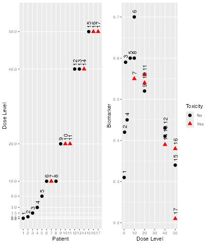

```r
print(plot(data))
```

Here we see that there seems to be a maximum biomarker response at around 10 mg already. In order to model this data, we consider a dual-endpoint model with a first-order random-walk (RW1) structure for the dose-biomarker relationship:

```r
model <- DualEndpointRW(
  mean = c(0, 1),
  cov = matrix(c(1, 0, 0, 1), nrow = 2),
  sigma2betaW =
    0.01,
  sigma2W =
    c(a = 0.1, b = 0.1),
  rho =
    c(a = 1, b = 1),
  rw1 = TRUE
)
```

We use a smoothing parameter $\sigma^{2}_{\beta_{W}} = 0.01$, an inverse-gamma prior $\mathrm{IG}(0.1, 0.1)$ on the biomarker variance $\sigma^{2}_{W}$ and a uniform prior (or $\mathrm{Beta}(1, 1)$ prior) on the correlation $\rho$ between the latent DLT and the biomarker variable.

As the dual-endpoint models are more complex, it is advisable to use a sufficiently long Markov chain for fitting them. Here we just use for illustration purposes a quite small Markov chain – again, for the real application, this would need to be at least 25 times longer!

```r
options <- McmcOptions(
  burnin = 100,
  step = 2,
  samples = 2000,
  rng_kind = "Mersenne-Twister",
  rng_seed = 3819
)
```

Then we can obtain the MCMC samples:

```r
samples <- mcmc(data, model, options)
```

And we check the convergence by picking a few of the fitted biomarker means and plotting their traceplots:

```r
data@nGrid
```

```
#> [1] 41
```

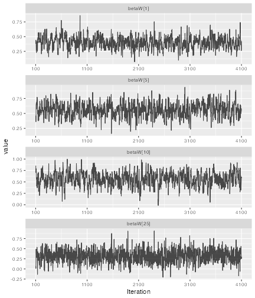

```r
betaWpicks <- get(samples, "betaW", c(1L, 5L, 10L, 25L))
ggs_traceplot(betaWpicks)
```

Here all 4 $\beta_{W,j}$ ($j=1, 5, 10, 25$) means, which are the biomarker means at the first, 5th, 10th and 25th gridpoint, respectively, seem to have converged, as the traceplots show. (Remember that `data@nGrid` gives the number of grid points.) So we can plot the model fit:

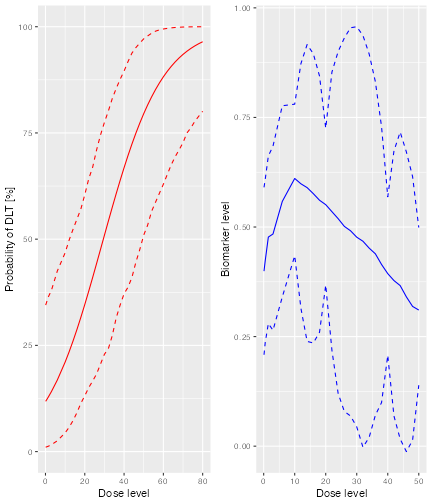

```r
print(plot(samples, model, data, extrapolate = FALSE))
```

We specify `extrapolate = FALSE` to focus the biomarker plot in the right panel on the observed dose range, so we don’t want to extrapolate the biomarker fit to higher dose levels. We can also look at the estimated biomarker precision $1 / \sigma^{2}_{W}$. For that we extract the precision `precW` and then use another `ggmcmc` function to create the histogram:

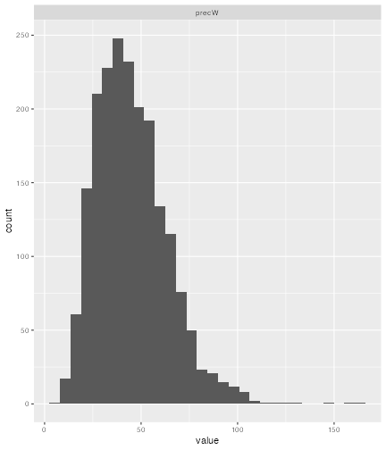

```r
ggs_histogram(get(samples, "precW"))
```

For the selection of the next best dose, a special class `NextBestDualEndpoint` has been implemented. It tries to maximize the biomarker response, under an NCRM-type safety constraint. If we want to have at least 90% of the maximum biomarker response, and a 25% maximum overdose probability for the next dose, we specify:

```r
myNextBest <- NextBestDualEndpoint(
  target = c(0.9, 1),
  overdose = c(0.35, 1),
  max_overdose_prob = 0.25
)
```

In our example, and assuming a dose limit of 50 mg given by the maximum allowable increments, the next dose can then be found as follows:

```r
nextDose <- nextBest(myNextBest,
  doselimit = 50,
  samples = samples,
  model = model,
  data = data
)
nextDose$value
```

```
#> [1] 10
```

A corresponding plot can be produced by printing the `plot` element of the returned list:

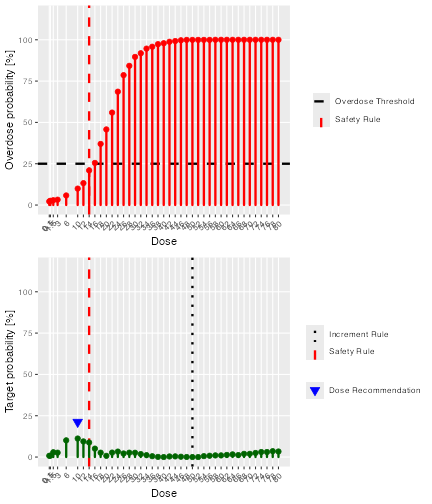

```r
print(nextDose$plot)
```

A corresponding stopping rule exists. When we have a certain probability to be above a relative biomarker target, then the `StoppingTargetBiomarker` rule gives back `TRUE` when queried if it has been fulfilled by the `stopTrial` function. For example, if we require at least 50% probability to be above 90% biomarker response, we specify:

```r
myStopping6 <- StoppingTargetBiomarker(
  target = c(0.9, 1),
  prob = 0.5
)
```

In this case, the rule has not been fulfilled yet, as we see here:

```r
stopTrial(myStopping6,
  dose = nextDose$value,
  samples, model, data
)
```

```
#> [1] FALSE
#> attr(,"message")
#> [1] "Probability for target biomarker is 11 % for dose 10 and thus below the required 50 %"
#> attr(,"report_label")
#> [1] "P(0.9 ≤ Biomarker ≤ 1) ≥ 0.5 (relative)"
```

Again, this dual-endpoint specific rule can be combined as required with any other stopping rule. For example, we could combine it with a maximum sample size of 40~patients:

```r
myStopping <- myStopping6 | StoppingMinPatients(40)
```

If one or both of the stopping rules are fulfilled, then the trial is stopped.

Let’s try to build a corresponding dual-endpoint design. We start with an empty data set, and use the relative increments rule defined in a previous section and use a constant cohort size of 3 patients:

```r
emptydata <- DataDual(doseGrid = data@doseGrid)
design <- DualDesign(
  model = model,
  data = emptydata,
  nextBest = myNextBest,
  stopping = myStopping,
  increments = myIncrements,
  cohort_size = CohortSizeConst(3),
  startingDose = 6
)
```

In order to study operating characteristics, we need to determine true biomarker and DLT probability functions. Here we are going to use a biomarker function from the beta family. Note that there is a corresponding `DualEndpointBeta` model class, that allows to have dual-endpoint designs with the beta biomarker response function. Have a look at the corresponding help page for more information on that. But let’s come back to our scenario definition:

```r
betaMod <- function(dose, e0, eMax, delta1, delta2, scal) {
  maxDens <- (delta1^delta1) * (delta2^delta2) / ((delta1 + delta2)^(delta1 + delta2))
  dose <- dose / scal
  e0 + eMax / maxDens * (dose^delta1) * (1 - dose)^delta2
}
trueBiomarker <- function(dose) {
  betaMod(dose, e0 = 0.2, eMax = 0.6, delta1 = 5, delta2 = 5 * 0.5 / 0.5, scal = 100)
}
trueTox <- function(dose) {
  pnorm((dose - 60) / 10)
}
```

We can draw the corresponding curves:

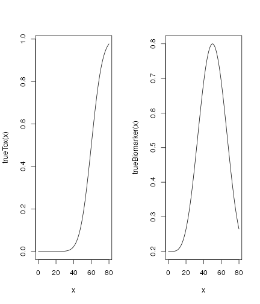

```r
par(mfrow = c(1, 2))
curve(trueTox(x), from = 0, to = 80)
curve(trueBiomarker(x), from = 0, to = 80)
```

So the biomarker response peaks at 50 mg, where the toxicity is still low. After deciding for a true correlation of $\rho=0$ and a true biomarker variance of $\sigma^{2}_{W} = 0.01$ (giving a high signal-to-noise ratio), we can start simulating trials (starting each with 6 mg):

```r
mySims <- simulate(design,
  trueTox = trueTox,
  trueBiomarker = trueBiomarker,
  sigma2W = 0.01,
  rho = 0,
  nsim = 10,
  parallel = FALSE,
  seed = 3,
  startingDose = 6,
  mcmcOptions =
    McmcOptions(
      burnin = 1000,
      step = 1,
      samples = 3000,
      rng_kind = "Mersenne-Twister",
      rng_seed = 3819
    )
)
```

Note that we are having a “small” MCMC option set here, in order to reduce simulation time — for the real application, this should be “larger”.

Plotting the result gives not only an overview of the final dose recommendations and trial trajectories, but also a summary of the biomarker variance and correlation estimates in the simulations:

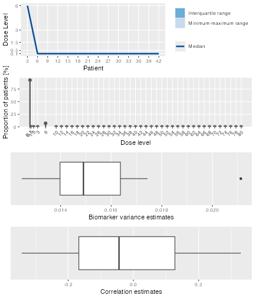

```r
print(plot(mySims))
```

Finally, a summary of the simulations can be obtained with the corresponding function:

```r
sumOut <- summary(mySims,
  trueTox = trueTox,
  trueBiomarker = trueBiomarker
)
sumOut
```

```
#> Summary of 10 simulations
#>
#> Target toxicity interval was 20, 35 %
#> Target dose interval corresponding to this was 51.6, 56.1
#> Intervals are corresponding to 10 and 90 % quantiles
#>
#> Number of patients overall : mean 42 (42, 42)
#> Number of patients treated above target tox interval : mean 0 (0, 0)
#> Proportions of DLTs in the trials : mean 0 % (0 %, 0 %)
#> Mean toxicity risks for the patients on active : mean 0 % (0 %, 0 %)
#> Doses selected as MTD : mean 0.1 (0.1, 0.1)
#> True toxicity at doses selected : mean 0 % (0 %, 0 %)
#> Proportion of trials selecting target MTD: 0 %
#> Dose most often selected as MTD: 0.1
#> Observed toxicity rate at dose most often selected: 0 %
#> Fitted toxicity rate at dose most often selected : mean 1 % (1 %, 2 %)
#> Overdose probability at selected dose : mean 0 % (0 %, 0 %)
#> Stop reason triggered:
#>  P(0.9 ≤ Biomarker ≤ 1) ≥ 0.5 (relative) :  0 %
#>  ≥ 40 patients dosed :  100 %
#> Fitted biomarker level at dose most often selected : mean 0.2 (0.2, 0.2)
```

We see here that all trials proceeded until the maximum sample size of 40 patients (reaching 42 because of the cohort size 3). The doses selected are lower than the toxicity target range, because here we were aiming for a biomarker target instead, and the true biomarker response peaked at 50 mg.

The corresponding plot looks as follows:

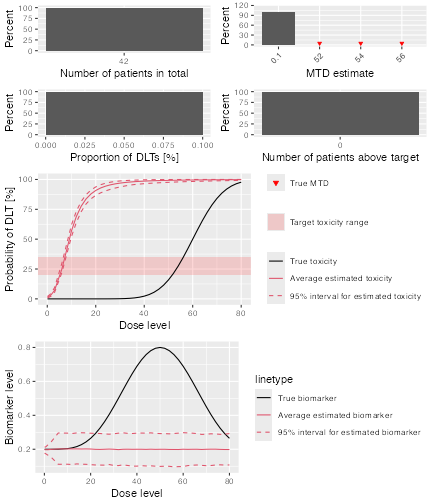

```r
print(plot(sumOut))
```

Again the warning here: the dual-endpoint designs are still experimental!

## 11.2 Dual-endpoint designs with separate models

In this subsection, we will look into the dose-escalation designs where we model the binary DLT responses and the continuous biomarker/efficacy responses separately. Here we hence assume that there is no correlation between the binary DLT and continuous efficacy responses.

First, we have to define the data sets for the dual responses using the `DataDual` function just like in the example given in the last subsection.

```r
data2 <- DataDual(doseGrid = seq(25, 300, 25))

data4 <- DataDual(
  x = c(25, 50, 50, 75, 100, 100, 225, 300),
  y = c(0, 0, 0, 0, 1, 1, 1, 1),
  ID = as.integer(1:8),
  cohort = as.integer(c(1, 2, 2, 3, 4, 4, 5, 6)),
  w = c(0.31, 0.42, 0.59, 0.45, 0.6, 0.7, 0.6, 0.52),
  doseGrid = seq(25, 300, 25)
)
```

In this example, `data2` is the empty data set where 12 dose levels, from 25 to 300 mg with increments of 25 mg are used. The variable `data4` contains the data set with both the binary DLT and continuous efficacy responses observations. The elements in the slot `x` are the dose levels where 8 subjects are treated. The elements in slot `y` represent the corresponding binary DLT responses observed for these 8 subjects and the elements in slot `w` represent the continuous efficacy responses obtained for the 8 subjects.

Similarly, we can also obtain a plot of the data sets using the `plot` function as described in the last subsection.

As described, we will model the two responses separately. In order to do so, we will only use models inheriting from the `ModelPseudo` class.

For the binary DLT responses, we can use any of the models inheriting from the `ModelTox` class. In the example below we will use models inheriting from the `LogisticIndepBeta` class which is the variable `DLTmodel` (or `newDLTmodel` with observations) given in previous examples.

The following commands show how we set up the `Effloglog` model. This is an efficacy model to describe the relationship between the efficacy responses to their corresponding dose levels on a double logarithmic (“log-log”) scale. This refers to a linear model with three unknown parameters: the intercept θ<sub>1</sub>, the slope θ<sub>2</sub> and the precision $\nu$ (inverse of the variance) of the efficacy responses. Similarly to other pseudo models, the data set has to be specified before setting up the model:

```r
Effmodel <- Effloglog(
  eff = c(1.223, 2.513),
  eff_dose = c(25, 300),
  nu = c(a = 1, b = 0.025),
  data = data2
)
```

For the specification of the prior pseudo data, two dose levels 25 and 300 mg are fixed and specified in the `eff_dose` slot. After eliciting the prior expected efficacy values at these two dose levels (e.g. by asking for experts’), these are specified in the `eff` slot. Here for example, 1.223 is the expected efficacy value for subjects treated at dose 25 mg and 2.513 is the expected efficacy value for subjects treated at 300 mg. The slot `nu` represents the prior precision of the efficacy responses. In this example, two positive scalars for $a$ and $b$ are specified suggesting the prior distribution of the precision is gamma with shape parameter $a=1$ and rate parameter $b=0.025$. Note here, since a gamma distribution is used as the prior distribution of $\nu$, the posterior distribution will again be a gamma distribution, because the gamma prior on the precision is conjugate to the normal likelihood. If a fixed value of the precision is preferred, a single positive scalar can also be specified in `nu` slot. Finally the `Data` slot is specified either with an empty data set or a data set with all currently available observations.

Similarly, we can also look at the structure of the Effmodel by applying the `str` function:

```r
str(Effmodel)
```

```
#> Formal class 'Effloglog' [package "crmPack"] with 13 slots
#>   ..@ eff      : num [1:2] 1.22 2.51
#>   ..@ eff_dose : num [1:2] 25 300
#>   ..@ nu       : Named num [1:2] 1 0.025
#>   .. ..- attr(*, "names")= chr [1:2] "a" "b"
#>   ..@ use_fixed: logi FALSE
#>   ..@ theta1   : num -1.41
#>   ..@ theta2   : num 2.25
#>   ..@ Pcov     : num [1:2, 1:2] NaN NaN NaN NaN
#>   .. ..- attr(*, "dimnames")=List of 2
#>   .. .. ..$ : chr [1:2] "(Intercept)" "log(log(x))"
#>   .. .. ..$ : chr [1:2] "(Intercept)" "log(log(x))"
#>   ..@ X        : num [1:2, 1:2] 1 1 1.17 1.74
#>   .. ..- attr(*, "dimnames")=List of 2
#>   .. .. ..$ : chr [1:2] "1" "2"
#>   .. .. ..$ : chr [1:2] "(Intercept)" "log(log(x))"
#>   .. ..- attr(*, "assign")= int [1:2] 0 1
#>   ..@ Y        : num [1:2] 1.22 2.51
#>   ..@ mu       : num [1:2] -1.41 2.25
#>   ..@ Q        : num [1:2, 1:2] 2 2.91 2.91 4.4
#>   .. ..- attr(*, "dimnames")=List of 2
#>   .. .. ..$ : chr [1:2] "(Intercept)" "log(log(x))"
#>   .. .. ..$ : chr [1:2] "(Intercept)" "log(log(x))"
#>   ..@ const    : num 0
#>   ..@ data     :Formal class 'DataDual' [package "crmPack"] with 12 slots
#>   .. .. ..@ w         : num(0)
#>   .. .. ..@ x         : num(0)
#>   .. .. ..@ y         : int(0)
#>   .. .. ..@ doseGrid  : num [1:12] 25 50 75 100 125 150 175 200 225 250 ...
#>   .. .. ..@ nGrid     : int 12
#>   .. .. ..@ xLevel    : int(0)
#>   .. .. ..@ placebo   : logi FALSE
#>   .. .. ..@ backfilled: logi(0)
#>   .. .. ..@ response  : int(0)
#>   .. .. ..@ ID        : int(0)
#>   .. .. ..@ cohort    : int(0)
#>   .. .. ..@ nObs      : int 0
```

Next, we will describe an example when a flexible semi-parametric function is used to describe the relationship between the efficacy values and their corresponding dose levels. The differences of the mean efficacy responses of neighboring dose levels are modeled by the either first or second order random walk models. This flexible model aims to capture different shapes of the dose-efficacy curve. We will estimate the mean efficacy responses obtained at each of the dose levels by MCMC sampling. % will be involved to obtain the prior and posterior distribution of all these mean efficacy responses.

This flexible form can be specified by using the `EffFlexi` class object. The `EffFlexi` class is inheriting from the `ModelEff` class and its prior is also specified with pseudo data:

```r
Effmodel2 <- EffFlexi(
  eff = c(1.223, 2.513),
  eff_dose = c(25, 300),
  sigma2W = c(a = 0.1, b = 0.1),
  sigma2betaW = c(a = 20, b = 50),
  rw1 = FALSE,
  data = data2
)
```

Here, similarly to above, we also fixed two dose levels 25 and 300 mg and supplied the prior expected efficacy responses 1.223 and 2.513. The variance of the efficacy responses $\sigma^2$ under this model can be specified with a single positive scalar value or two positive scalar values for the shape $a$ and the scale $b$ parameters of the inverse gamma distribution in the slot `sigma2`. In here, we specified the variance of the efficacy responses with the inverse gamma distribution with shape parameter $a=0.1$ and scale parameter $b=0.1$. Then, the variance of the random walk model $\sigma^2_{\beta_W}$ can also be specified either with a single positive scalar or two positive scalar for the parameters of the inverse gamma distribution in the slot `sigma2betaW`. In here, we specified the variance of the random walk model with the inverse gamma distribution with shape parameter $a=20$ and scale parameter $b=50$. In addition, we can also specify how we would like to smooth the mean efficacy response function. Either the first order (with `RW1`) or the second order (with `RW2`) random walk model can be used to describe the relationship between the neighbouring mean efficacy responses and is specified in the the slot `smooth`. As seen in our example, `RW2`, the second order random walk model is used. Finally, we also have to specify the data set in `Data` to be used for the model which is `data2` in this example.

The structure of the `EffFlexi` model object is as follows:

```r
str(Effmodel2)
```

```
#> Formal class 'EffFlexi' [package "crmPack"] with 10 slots
#>   ..@ eff        : num [1:2] 1.22 2.51
#>   ..@ eff_dose   : num [1:2] 25 300
#>   ..@ sigma2W    : Named num [1:2] 0.1 0.1
#>   .. ..- attr(*, "names")= chr [1:2] "a" "b"
#>   ..@ sigma2betaW: Named num [1:2] 20 50
#>   .. ..- attr(*, "names")= chr [1:2] "a" "b"
#>   ..@ use_fixed  : Named logi [1:2] FALSE FALSE
#>   .. ..- attr(*, "names")= chr [1:2] "sigma2W" "sigma2betaW"
#>   ..@ rw1        : logi FALSE
#>   ..@ X          : int [1:2, 1:12] 1 0 0 0 0 0 0 0 0 0 ...
#>   ..@ RW         : num [1:12, 1:12] 1 -2 1 0 0 0 0 0 0 0 ...
#>   ..@ RW_rank    : int 10
#>   ..@ data       :Formal class 'DataDual' [package "crmPack"] with 12 slots
#>   .. .. ..@ w         : num(0)
#>   .. .. ..@ x         : num(0)
#>   .. .. ..@ y         : int(0)
#>   .. .. ..@ doseGrid  : num [1:12] 25 50 75 100 125 150 175 200 225 250 ...
#>   .. .. ..@ nGrid     : int 12
#>   .. .. ..@ xLevel    : int(0)
#>   .. .. ..@ placebo   : logi FALSE
#>   .. .. ..@ backfilled: logi(0)
#>   .. .. ..@ response  : int(0)
#>   .. .. ..@ ID        : int(0)
#>   .. .. ..@ cohort    : int(0)
#>   .. .. ..@ nObs      : int 0
```

The slot and the names are shown which can be accessed with the `@` operator. The value ‘FALSE’ of the slot `useFixed` shows that both the variance of the efficacy response `sigma2` and the variance of the random walk model `sigma2betaW`are not fixed, but estimated and assigned an inverse gamma prior distribution in this model. The slot`useRW1`also gives a 'FALSE' value which means that the second order random walk model has been used to model the smooth dose-response function. In addition, the (only internally required) random walk difference matrix and the rank of this matrix are also shown in the slot`RWmat`and`RWmatRank`, respectively.

As discussed, the posterior estimates for model parameters specified under `ModelPseudo` class (except the `EffFlexi` model class) can be obtained as the modal estimates or via MCMC sampling. In here, we will first show how we obtain the estimates of the parameters via MCMC sampling. (Similarly, we can also use the `mcmc` function to obtain prior and posterior samples of the `Effloglog` and the `EffFlexi` models.) % using Effmodel or Effmodel2, respectively with data2 and options specified earlier

```r
Effsamples <- mcmc(data = data2, model = Effmodel, options)
Effsamples2 <- mcmc(data = data2, model = Effmodel2, options)
```

```r
Effpostsamples <- mcmc(data = data2, model = Effmodel, options)
Effpostsamples2 <- mcmc(data = data2, model = Effmodel2, options)
```

Under the `Effloglog` (Effmodel) model, samples of the intercept θ<sub>1</sub>, the slope θ<sub>2</sub> of the efficacy linear log-log model and the precision $\nu$ of the efficacy responses can be obtained. For the `EffFlexi` (Effmodel2) model, the samples of the mean efficacy responses at all dose levels, the variance $\sigma^2$ (sigma2) of the efficacy responses and the variance $\sigma^2_{\beta_W}$ (sigma2betaW) of the random walk model are obtained. It is also again possible to look at the structure (`str`) and extract (`get`) and obtain plots (`ggs_traceplot` and `ggs_autocorrelation`) of the samples of the parameters.

If no MCMC sampling is involved, the prior or the posterior modal estimates can be obtained in the output of the models. If some observations for both responses are available, they can be put in a `DataDual` data set, and given to the `Data` slot under each model. We can also do so by updating the current model with the new observations using the `update` function. Then the prior or the posterior modal estimates of the model parameters can be obtained using the `@` operator of the model. For example, for the `Effloglog` class model:

```r
newEffmodel <- update(object = Effmodel, data = data4)
newEffmodel@theta1
```

```
#> [1] -2.81695
```

```r
newEffmodel@theta2
```

```
#> [1] 2.709524
```

```r
newEffmodel@nu
```

```
#>         a         b
#> 3.0000000 0.9832955
```

The posterior modal estimates of θ<sub>1</sub> and θ<sub>2</sub> and the updated values of parameters of the gamma distribution of $\nu$ can be read now from the output above.

Similarly we can update with new data for the `EffFlexi` class model:

```r
newEffmodel2 <- update(object = Effmodel2, data = data4)
newEffmodel2@RW
```

```
#>       [,1] [,2] [,3] [,4] [,5] [,6] [,7] [,8] [,9] [,10] [,11] [,12]
#>  [1,]    1   -2    1    0    0    0    0    0    0     0     0     0
#>  [2,]   -2    5   -4    1    0    0    0    0    0     0     0     0
#>  [3,]    1   -4    6   -4    1    0    0    0    0     0     0     0
#>  [4,]    0    1   -4    6   -4    1    0    0    0     0     0     0
#>  [5,]    0    0    1   -4    6   -4    1    0    0     0     0     0
#>  [6,]    0    0    0    1   -4    6   -4    1    0     0     0     0
#>  [7,]    0    0    0    0    1   -4    6   -4    1     0     0     0
#>  [8,]    0    0    0    0    0    1   -4    6   -4     1     0     0
#>  [9,]    0    0    0    0    0    0    1   -4    6    -4     1     0
#> [10,]    0    0    0    0    0    0    0    1   -4     6    -4     1
#> [11,]    0    0    0    0    0    0    0    0    1    -4     5    -2
#> [12,]    0    0    0    0    0    0    0    0    0     1    -2     1
```

The `plot` function can also be applied to the `Effloglog` model class or the `EffFlexi` model class objects, when samples of the parameters are generated under all these models:

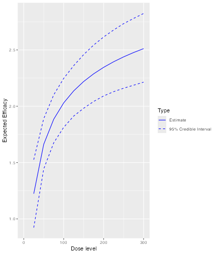

```r
print(plot(Effpostsamples, newEffmodel, data4))
```

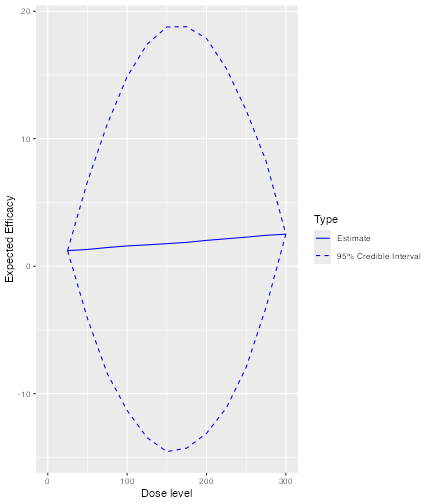

```r
print(plot(Effpostsamples2, newEffmodel2, data4))
```

In addition, we can also plot the fitted dose-efficacy curve using the prior or the posterior modal estimates of the model parameters when no MCMC sampling is used. For example, using `Effmodel` and data set `data2` specified earlier:

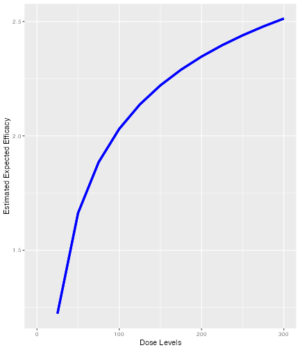

```r
print(plot(data2, Effmodel))
```

Since no samples are involved, only the curves using the prior or posterior modal estimates of the parameters are produced, and no 95% credibility intervals are provided.

Furthermore, we can also plot the estimated DLT probability and efficacy curve side by side using the `plotDualResponses` function. For example, using the `DLTmodel`, `Effmodel` and `data2` specified in earlier examples:

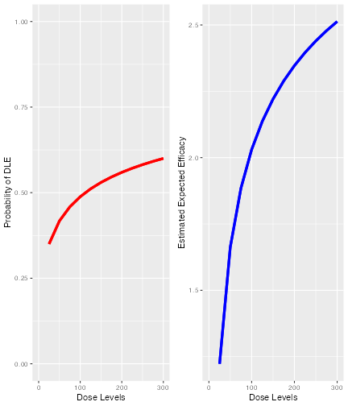

```r
plotDualResponses(
  DLEmodel = DLTmodel,
  Effmodel = Effmodel, data = data2
)
```

When the MCMC samples are used, we have:

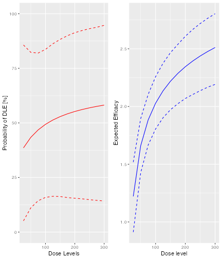

```r
plotDualResponses(
  DLEmodel = DLTmodel, DLEsamples = DLTsamples,
  Effmodel = Effmodel, Effsamples = Effsamples, data = data2
)
```

Next we will talk about the dose escalation rules when two separate models are used for the dual responses. All `Increments`, `CohortSize` and the `Stopping` rules classes described earlier can be applied here. We will now look into additional `nextBest` and `Stopping` classes rules that we can use in this situation.

In here, the decision of choosing the next best dose for administration is based on a gain function we defined (Yeung et al. 2015). This gain function represents a trade-off between the DLT and efficacy responses such that we will allocate the dose which gives the best trade-off between these responses. In other words, the dose which gives the maximum gain value will be the dose allocated to the next cohort of subjects. The basic ideas of this rules are as follows. % old text: Assume that no DLT is observed in a subject, the gain value observed at a particular dose level is obtained by multiplying the probability of no DLT observed at this dose levels and all expected efficacy responses when no DLT is observed at this particular dose level. %new: The gain value at a particular dose level is obtained by multiplying the probability of no DLT at this dose level and the expected efficacy response at this dose level. As the data accumulates in the trial, the estimate of the gain function will improve. This gain function consists of two components, one part is about the DLT responses and the other about the efficacy response. It depends on the values obtained in each of the components which will affect the values of the gain.

For example, the most ideal case is that both the probability of no DLT and the expected value of the efficacy response are high. The gain value obtained will then be very high. This is the reason why the dose which gives the maximum gain value should be allocated to the next cohort of subjects.

We can plot the gain function given a DLT model specified under the `ModelTox` class and an efficacy model specified under the `ModelEff` class using the `plotGain` function. For example, using the variables `newDLTmodel`, `newEffmodel` and the data set with observations, `data4`, specified in earlier examples, we have:

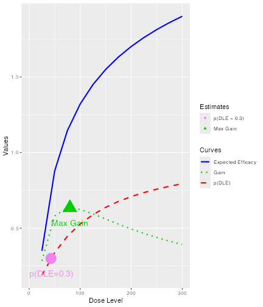

```r
plotGain(DLEmodel = newDLTmodel, Effmodel = newEffmodel, data = data4)
```

This is a case where no MCMC sampling is involved such that the prior and posterior modal estimates of the model parameters are used.

There are two implemented `nextBest` rules for the dual responses using the gain function: the `NextBestMaxGain` and the `NextBestMaxGainSamples` class object. The `NextBestMaxGain` is used when no MCMC sampling are involved and we will use the prior or the posterior modal estimates of the model parameters to obtain the gain values at each of the dose levels, while the `NextBestMaxGainSamples` is used when MCMC sampling is involved to obtain the posterior estimates. For example, when no MCMC sampling is involved:

```r
GainNextBest <- NextBestMaxGain(
  prob_target_drt = 0.35,
  prob_target_eot = 0.3
)
```

To use the `NextBestMaxGain`, we have to specify the target probability of the occurrence of a DLT to be used during the trial or at the end of the trial. In this example, the target probability of DLT to be used during the trial and at the end of the trial are 0.35 and 0.3, respectively. Therefore, under this rule we will suggest the dose level which gives the maximum gain value and has a probability of DLT less than or equal to 0.35 to administer to the next cohort of subjects. At the end of the trial, we will recommend the dose with maximum gain value and probability of DLT less than or equal to 0.3. In order to derive the next best dose for administration, we have to use the `nextBest` function with this `NextBestMaxGain` object given the doselimit, both the DLT and the efficacy models and the data set, which includes all currently available observations:

```r
doseRecGain <- nextBest(GainNextBest,
  doselimit = max(data4@doseGrid),
  model = newDLTmodel,
  model_eff = newEffmodel,
  data = data4
)
```

The results will be a list of numerical values with a plot illustrating how the next best dose was computed. The list of numerical values include the next best dose suggested, the values of the target probabilities of DLT used during and at the end of a trial. Furthermore, the estimated doses for these two targets, as well as the “Gstar” estimated dose (the dose with gives the maximum gain value) are provided along with the corresponding dose level in the dose grid for the above three estimates. We can also get to see the plot about the next best dose recommendation using the `$` operator.

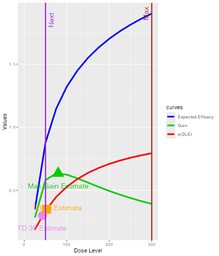

```r
doseRecGain$plot
```

As usual, we have the solid red, blue and green lines as the curves to represent the relationship between the probability of DLT, the mean efficacy response and gain values, respectively, to their corresponding dose levels. The vertical line in purple shows the next best dose suggested for administration and the vertical brown line shows the maximum allowable dose level to be administered to the next cohort of subjects. Furthermore, the circle and the square on the DLT curve also show the current estimate of the estimated TD30 and TD35.

Next we will look at the `NextBestMaxGainSamples` class object when MCMC sampling is involved. In the following code, we specify the target probabilities of DLT used during or at the end of a trial to be 0.35 and 0.3 again, and we specify that the 30% posterior quantile will be used as the estimate for the TD35 and TD30, while we specify the 50% posterior quantile for the Gstar estimate:

```r
GainsamplesNextBest <- NextBestMaxGainSamples(
  prob_target_drt = 0.35,
  prob_target_eot = 0.3,
  derive = function(TDsamples) {
    as.numeric(quantile(TDsamples, prob = 0.3))
  },
  mg_derive = function(Gstarsamples) {
    as.numeric(quantile(Gstarsamples, prob = 0.5))
  }
)
```

Note that the two functions, `derive` and `mg_derive` have to be specified to derive the corresponding estimates from the posterior samples.

Again, the generic function `nextBest` will be used together with this rule object to derive the next best dose:

```r
doseRecGainSamples <- nextBest(GainsamplesNextBest,
  doselimit = max(data4@doseGrid),
  model = newDLTmodel,
  samples = DLTpostsamples,
  model_eff = newEffmodel,
  samples_eff = Effpostsamples,
  data = data4
)
```

```
#> [1] "Estimated TD 30 = 18.6611868271306 not within dose grid"
```

The list of numerical results given in the output will be the same as those given using `NextBestMaxGain` class object which includes the next dose suggested, the current estimates of TD30, TD35 and Gstar and their corresponding dose levels at dose Grid. We can also see the plot:

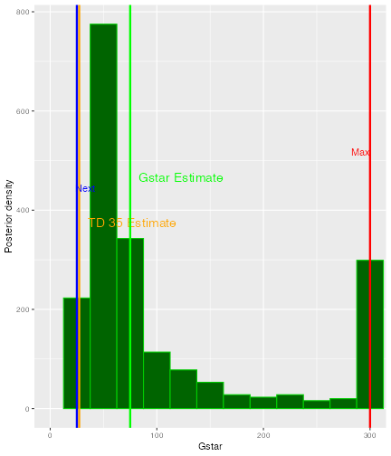

```r
doseRecGainSamples$plot
```

In this plot, the posterior distribution of Gstar is shown as a histogram. The vertical lines on the plot show all current estimates of TD30, TD35 and Gstar. In addition, the next dose and the maximum allowable dose are also given in blue and red lines, respectively.

Next, we will introduce some further `Stopping` rules that can be applied to the above two classes of escalation rules. After the escalation based on two responses and two separate pseudo DLT and efficacy models, we will select one dose, which is the minimum of the estimate of TD30 (TDtargetEndOfTrial) and the optimal gain dose (Gstar) as the recommended dose for potential further clinical trials. The main feature of these stopping rules is that the trial could be stopped if the current estimates of this selected quantity is ‘accurate’ enough. In particular, we will also consider the ratio of the 95% credibility interval bounds of its current estimate. The smaller this ratio, the more accurate is the estimate.

For example, we would like to stop our trial if the ratio is less than or equal to 5. The functions `StoppingMaxGainCIRatio` is used for this purpose:

```r
myStopping7 <- StoppingMaxGainCIRatio(target_ratio = 5, prob_target = 0.3)
myStopping8 <- myStopping7 | StoppingMinPatients(72)
```

To note here, at the moment the class `stoppingMaxGainCIRatio` cannot be used together with other `stopping` class rules with the “and” operator `&` and the `or` operator `|` (this is still under development).

Similarly, the `stopTrial` function can then be used in order to determine if the rule has been fulfilled:

```r
stopTrial(
  stopping = myStopping7, dose = doseRecGain$next_dose, model = newDLTmodel,
  data = data4, Effmodel = newEffmodel
)
```

```
#> [1] FALSE
#> attr(,"message")
#> [1] "Gstar estimate is 79.7805 with 95% CI ( 21.5588 , 295.2361 ) and its ratio = 13.6945"
#> [2] "TDtargetEndOfTrial estimate is  42.6813 with 95% CI ( 11.0662 , 164.618 ) and its ratio= 14.8758"
#> [3] "TDtargetEndOfTrial estimate is smaller with ratio = 14.8758 which is  greater than target_ratio = 5"
#> attr(,"report_label")
#> [1] "GStar 5 for 0.3 target prob"
```

```r
stopTrial(
  stopping = myStopping7,
  dose = doseRecGainSamples$next_dose,
  samples = DLTpostsamples,
  model = newDLTmodel,
  data = data4,
  TDderive = function(TDsamples) {
    quantile(TDsamples, prob = 0.3)
  },
  Effmodel = newEffmodel,
  Effsamples = Effpostsamples,
  Gstarderive = function(Gstarsamples) {
    quantile(Gstarsamples, prob = 0.5)
  }
)
```

```
#> [1] FALSE
#> attr(,"message")
#> [1] "Gstar estimate is 75 with 95% CI ( 25 , 300 ) and its ratio = 12"
#> [2] "TDtargetEndOfTrial estimate is  18.6612 with 95% CI ( 6e-04 , 10459.1345 ) and its ratio= 17110373.1537"
#> [3] "TDtargetEndOfTrial estimate is smaller with ratio = 17110373.1537  which is  greater than target_ratio = 5"
#> attr(,"report_label")
#> [1] "GStar 5 for 0.3 target prob"
```

There are two functions which we can used. The `DualResponsesDesign` can be used without MCMC samples, while `DualResponsesSamplesDesign` can be used when MCMC samples are involved. For example, we use the object `Effmodel` of the `Effloglog` class specified earlier as the efficacy model in the following code:

```r
design1 <- DualResponsesDesign(
  nextBest = GainNextBest,
  model = DLTmodel,
  eff_model = Effmodel,
  data = data2,
  stopping = myStopping7,
  increments = myIncrements1,
  cohort_size = mySize,
  startingDose = 25
)

design2 <- DualResponsesSamplesDesign(
  nextBest = GainsamplesNextBest,
  model = DLTmodel,
  eff_model = Effmodel,
  data = data2,
  stopping = myStopping8,
  increments = myIncrements1,
  cohort_size = mySize,
  startingDose = 25
)
```

We can use the function `DualResponsesSamplesDesign` to specify a design when an efficacy model is specified under the `EffFlexi` class object. For example, we use the object `Effmodel2` of the `EffFlexi` class specified in earlier examples here:

```r
design3 <- DualResponsesSamplesDesign(
  nextBest = GainsamplesNextBest,
  model = DLTmodel,
  eff_model = Effmodel2,
  data = data2,
  stopping = myStopping8,
  increments = myIncrements1,
  cohort_size = mySize,
  startingDose = 25
)
```

We specified the above three designs using all previous rules for nextBest (the escalation rule), stopping, increments and cohort size.

Next, we have to specify the scenarios for simulations. For example, for simulations using the DLT model and efficacy model from the `LogisticIndepBeta` and `Effloglog` objects, respectively, we can specify the scenario as below:

```r
myTruthDLT <- probFunction(DLTmodel, phi1 = -53.66584, phi2 = 10.50499)
myTruthEff <- efficacyFunction(Effmodel, theta1 = -4.818429, theta2 = 3.653058)

myTruthGain <- function(dose) {
  return(myTruthEff(dose) * (1 - myTruthDLT(dose)))
}
```

The true DLT, efficacy and gain curves can be obtained. We can see the corresponding curves as

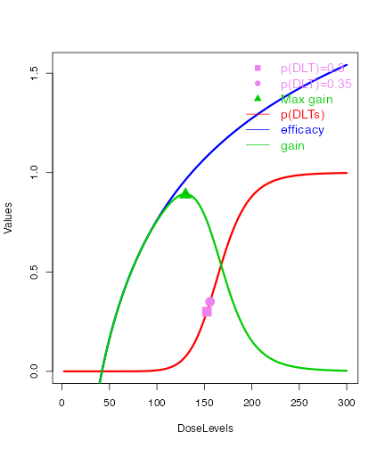

```r
TruthTD <- doseFunction(DLTmodel, phi1 = -53.66584, phi2 = 10.50499)

GAIN <- function(xi) {
  -(-4.8218429 + 3.653058 * log(xi)) / (1 + exp(-53.66584 + 10.50499 * xi))
}
Txi <- (optim(1, GAIN, method = "BFGS")$par)
maxg <- (optim(1, GAIN, method = "BFGS")$value)
gstar <- exp(Txi)
td30 <- TruthTD(0.3)
td35 <- TruthTD(0.35)
DoseLevels <- seq(2, 300, 1)
plot(DoseLevels, myTruthDLT(DoseLevels),
  col = "red", type = "l", lwd = 3, ylab = "Values",
  ylim = c(0, max(1, max(myTruthEff(DoseLevels))))
)
points(td30, 0.3, col = "violet", pch = 15, cex = 2)
points(td35, 0.35, col = "violet", pch = 16, cex = 2)
lines(DoseLevels, myTruthEff(DoseLevels), col = "blue", type = "l", lwd = 3)
lines(DoseLevels, myTruthGain(DoseLevels), col = "green3", type = "l", lwd = 3)
points(gstar, -maxg, col = "green3", pch = 17, cex = 2)
legend("topright",
  bty = "n", cex = 1.2, c(
    "p(DLT)=0.3", "p(DLT)=0.35", "Max gain", "p(DLTs)",
    "efficacy", "gain"
  ), text.col = c("violet", "violet", "green3", "red", "blue", "green3"),
  pch = c(15, 16, 17, NA, NA, NA), lty = c(NA, NA, NA, 1, 1, 1), col = c("violet", "violet", "green3", "red", "blue", "green3")
)
```

Using all the above commands, we can obtained the DLT (red), efficacy(blue) and gain (green) curves and also their corresponding true values for the TD30 (TDtargetEndOfTrial), TD35 (TDtargetDuringTrial) and the Gstar. In addition, the above scenario for DLT and efficacy can be used for both cases (modal estimates or MCMC samples).

If the `EffFlexi` class object will be used for the simulations. Using the same DLT scenario and a new efficacy scenario will be specified such that

```r
myTruthEff1 <- c(
  -0.5478867, 0.1645417, 0.5248031, 0.7604467,
  0.9333009, 1.0687031, 1.1793942, 1.2726408,
  1.3529598, 1.4233411, 1.4858613, 1.5420182
)

d1 <- data2@doseGrid
myTruthGain1 <- myTruthEff1 * (1 - myTruthDLT(d1))
```

The corresponding curves can also be plotted as:

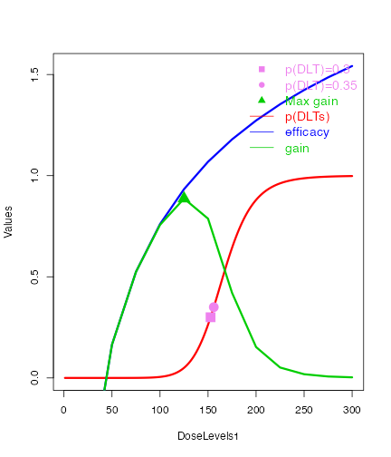

```r
maxg1 <- max(myTruthGain1)
gstar1 <- data2@doseGrid[which.max(myTruthGain1)]
DoseLevels1 <- seq(1, 300, 1)
TruthTD <- doseFunction(DLTmodel, phi1 = -53.66584, phi2 = 10.50499)
td30 <- TruthTD(0.3)
td35 <- TruthTD(0.35)
plot(DoseLevels1, myTruthDLT(DoseLevels1),
  col = "red", type = "l",
  lwd = 3, ylab = "Values", ylim = c(0, max(1, max(myTruthEff1)))
)
points(td30, 0.3, col = "violet", pch = 15, cex = 2)
points(td35, 0.35, col = "violet", pch = 16, cex = 2)
lines(d1, myTruthEff1, col = "blue", type = "l", lwd = 3)
lines(d1, myTruthGain1, col = "green3", type = "l", lwd = 3)
points(gstar1, maxg1, col = "green3", pch = 17, cex = 2)
legend("topright",
  bty = "n", cex = 1.2, c(
    "p(DLT)=0.3", "p(DLT)=0.35",
    "Max gain", "p(DLTs)", "efficacy", "gain"
  ), text.col = c(
    "violet", "violet",
    "green3", "red", "blue", "green3"
  ), pch = c(15, 16, 17, NA, NA, NA),
  lty = c(NA, NA, NA, 1, 1, 1), col = c("violet", "violet", "green3", "red", "blue", "green3")
)
```

Similarly, we also get the DLT, efficacy and gain values and the corresponding real values of the TD30, TD35 and Gstar.

Then after establishing the real scenarios, we can simulate the trials. First, we will look at two examples when the `Effloglog` class object is used as the efficacy model. We will show first an example when no MCMC samples are involved:

```r
Sim1 <- simulate(
  object = design1,
  args = NULL,
  trueDLE = myTruthDLT,
  trueEff = myTruthEff,
  trueNu = 1 / 0.025,
  nsim = 10,
  seed = 819,
  parallel = FALSE
)
```

The `simulate` function is used in all cases to simulate trials with specified scenarios. From the above, we specified the true precision (`trueNu`) of the efficacy responses be 1/0.025. In other words, we used a value of 0.025 as the true variance of the efficacy responses in this simulation. For the arguments `args`,`nsim`, `seed` and `parallel`, please refer to earlier examples for details for their specification and description details.

When MCMC samples are used, we can also specify the simulations in a similar way with an additional argument `mcmcOptions` such that we have

```r
Sim2 <- simulate(
  object = design2,
  args = NULL,
  trueDLE = myTruthDLT,
  trueEff = myTruthEff,
  trueNu = 1 / 0.025,
  nsim = 10,
  seed = 819,
  mcmcOptions = options,
  parallel = FALSE
)
```

When the `EffFlexi` class object is used as the efficacy model, we will generate the simulations as follows:

```r
Sim3 <- simulate(
  object = design3,
  args = NULL,
  trueDLE = myTruthDLT,
  trueEff = myTruthEff1,
  trueSigma2 = 0.025,
  trueSigma2betaW = 1,
  mcmcOptions = options,
  nsim = 10,
  seed = 819,
  parallel = FALSE
)
```

For the specification of the arguments `object`, `args`, `trueDLE`, `trueEff`, `mcmcOptions`,`nsim`,`seed`,`parallel` please refer to earlier examples for details. In addition, two arguments have to be used when the `EffFlexi` class efficacy model is used for the simulations: First, `trueSigma2` has to be specified as the true variance of the efficacy responses and `trueSigma2betaW` as the true variance of the random walk model to be used in the simulation.

Furthermore, we can also plot, summarize and plot the summary of the simulated results using `plot` and `summary` function:

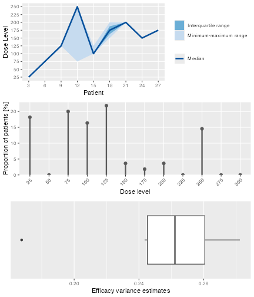

```r
plot(Sim1)
```

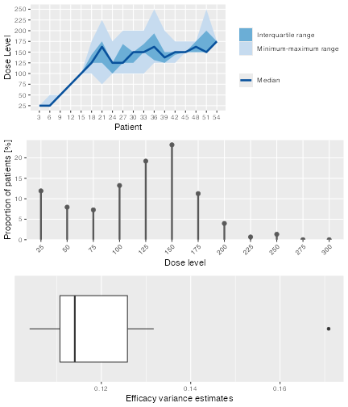

```r
plot(Sim2)
```

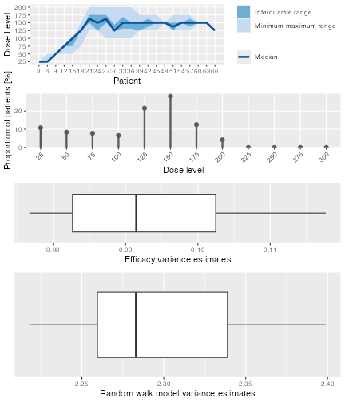

```r
plot(Sim3)
```

The plots give an overview of the final dose recommendations and trial trajectories. In addition, they also give a summary of the efficacy variance and also the random walk model variance when the `EffFlexi` class object is used for the efficacy model.

Then, the summary and the plot of the summary of the simulations can be obtained by:

```r
Sum1 <- summary(Sim1,
  trueDLE = myTruthDLT,
  trueEff = myTruthEff
)
Sum1
```

```
#> Summary of 10 simulations
#>
#> Target probability of DLE p(DLE) used at the end of a trial was 30 %
#> The dose level corresponds to the target p(DLE) used at the end of a trial, TDEOT, was 152.6195
#> TDEOT at dose Grid was 150
#> Target p(DLE) used during a trial was 35 %
#> The dose level corresponds to the target p(DLE) used during a trial, TDDT, was 155.972
#> TDDT at dose Grid was 150
#> Number of patients overall : mean 16 (15, 19)
#> Number of patients treated above the target p(DLE) used at the end of a trial : mean 3 (3, 3)
#> Number of patients treated above the target p(DLE) used during a trial : mean 3 (3, 3)
#> Proportions of observed DLT in the trials : mean 21 % (20 %, 23 %)
#> Mean toxicity risks for the patients : mean 21 % (20 %, 21 %)
#> Doses selected as TDEOT : mean 100 (97.5, 102.5)
#> True toxicity at TDEOT : mean 1 % (0 %, 1 %)
#> Proportion of trials selecting the TDEOT: 0 %
#> Proportion of trials selecting the TDDT: 0 %
#> Dose most often selected as TDEOT: 100
#> Observed toxicity rate at dose most often selected: 0 %
#> Fitted probabilities of DLE at dose most often selected : mean 24 % (24 %, 24 %)
#> The summary table of the final TDEOT across all simulations
#>     Min. 1st Qu.  Median    Mean 3rd Qu.    Max.
#>    98.18  123.81  123.81  122.23  123.81  133.63
#> The summary table of the final ratios of the TDEOT across all simulations
#>     Min. 1st Qu.  Median    Mean 3rd Qu.    Max.
#>    3.849   4.447   4.447   4.442   4.447   4.993
#> The summary table of the final TDDT across all simulations
#>     Min. 1st Qu.  Median    Mean 3rd Qu.    Max.
#>    118.2   144.4   144.4   143.5   144.4   161.5
#> The summary table of dose levels, the optimal dose
#>  to recommend for subsequent study across all simulations
#>     Min. 1st Qu.  Median    Mean 3rd Qu.    Max.
#>    98.18  123.81  123.81  122.23  123.81  133.63
#> The summary table of the final ratios of the optimal dose for stopping across
#>                   all simulations
#>     Min. 1st Qu.  Median    Mean 3rd Qu.    Max.
#>    3.849   4.447   4.447   4.442   4.447   4.993
#>
#> Stop reason triggered:
#>  GStar 5 for 0.3 target prob :  100 %
#> Target Gstar, the dose which gives the maximum gain value was 130.0097
#> Target Gstar at dose Grid was 125
#> The summary table of the final Gstar across all simulations
#>     Min. 1st Qu.  Median    Mean 3rd Qu.    Max.
#>    142.9   146.7   152.1   152.6   153.1   178.6
#> The summary table of the final ratios of the Gstar across all simulations
#>     Min. 1st Qu.  Median    Mean 3rd Qu.    Max.
#>    6.807   6.985   7.188   7.691   7.472  10.729
#> The summary table of dose levels, the optimal dose
#>  to recommend for subsequent study across all simulations
#>     Min. 1st Qu.  Median    Mean 3rd Qu.    Max.
#>    98.18  123.81  123.81  122.23  123.81  133.63
#> The summary table of the final ratios of the optimal dose for stopping across
#>         all simulations
#>     Min. 1st Qu.  Median    Mean 3rd Qu.    Max.
#>    3.849   4.447   4.447   4.442   4.447   4.993
#> Fitted expected efficacy level at dose most often selected : mean 0.9 (0.9, 1)
#> Stop reason triggered:
#>  GStar 5 for 0.3 target prob :  100 %
```

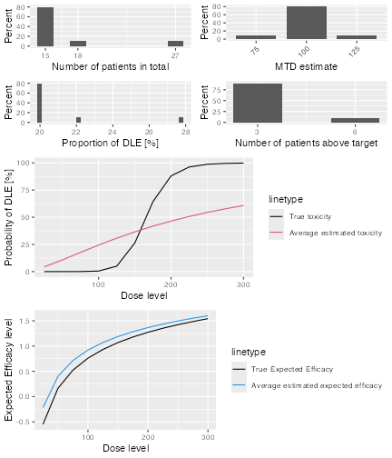

```r
print(plot(Sum1))
```

```r
Sum2 <- summary(Sim2,
  trueDLE = myTruthDLT,
  trueEff = myTruthEff
)
Sum2
```

```
#> Summary of 10 simulations
#>
#> Target probability of DLE p(DLE) used at the end of a trial was 30 %
#> The dose level corresponds to the target p(DLE) used at the end of a trial, TDEOT, was 152.6195
#> TDEOT at dose Grid was 150
#> Target p(DLE) used during a trial was 35 %
#> The dose level corresponds to the target p(DLE) used during a trial, TDDT, was 155.972
#> TDDT at dose Grid was 150
#> Number of patients overall : mean 45 (36, 51)
#> Number of patients treated above the target p(DLE) used at the end of a trial : mean 8 (3, 12)
#> Number of patients treated above the target p(DLE) used during a trial : mean 8 (3, 12)
#> Proportions of observed DLT in the trials : mean 19 % (17 %, 20 %)
#> Mean toxicity risks for the patients : mean 19 % (15 %, 25 %)
#> Doses selected as TDEOT : mean 120 (100, 125)
#> True toxicity at TDEOT : mean 4 % (1 %, 5 %)
#> Proportion of trials selecting the TDEOT: 0 %
#> Proportion of trials selecting the TDDT: 0 %
#> Dose most often selected as TDEOT: 125
#> Observed toxicity rate at dose most often selected: 6 %
#> Fitted probabilities of DLE at dose most often selected : mean 25 % (23 %, 27 %)
#> The summary table of the final TDEOT across all simulations
#>     Min. 1st Qu.  Median    Mean 3rd Qu.    Max.
#>    115.0   127.6   135.9   132.4   138.6   143.8
#> The summary table of the final ratios of the TDEOT across all simulations
#>     Min. 1st Qu.  Median    Mean 3rd Qu.    Max.
#>        1       1       1       1       1       1
#> The summary table of the final TDDT across all simulations
#>     Min. 1st Qu.  Median    Mean 3rd Qu.    Max.
#>    133.2   151.0   155.9   154.2   159.3   168.8
#> The summary table of dose levels, the optimal dose
#>  to recommend for subsequent study across all simulations
#>     Min. 1st Qu.  Median    Mean 3rd Qu.    Max.
#>    115.0   127.6   135.9   132.4   138.6   143.8
#> The summary table of the final ratios of the optimal dose for stopping across
#>                   all simulations
#>     Min. 1st Qu.  Median    Mean 3rd Qu.    Max.
#>        1       1       1       1       1       1
#>
#> Stop reason triggered:
#>  GStar 5 for 0.3 target prob :  100 %
#>  ≥ 72 patients dosed :  0 %
#> Target Gstar, the dose which gives the maximum gain value was 130.0097
#> Target Gstar at dose Grid was 125
#> The summary table of the final Gstar across all simulations
#>     Min. 1st Qu.  Median    Mean 3rd Qu.    Max.
#>    150.0   175.0   187.5   182.5   200.0   200.0
#> The summary table of the final ratios of the Gstar across all simulations
#>     Min. 1st Qu.  Median    Mean 3rd Qu.    Max.
#>      2.4     2.4     2.4     2.4     2.4     2.4
#> The summary table of dose levels, the optimal dose
#>  to recommend for subsequent study across all simulations
#>     Min. 1st Qu.  Median    Mean 3rd Qu.    Max.
#>    115.0   127.6   135.9   132.4   138.6   143.8
#> The summary table of the final ratios of the optimal dose for stopping across
#>         all simulations
#>     Min. 1st Qu.  Median    Mean 3rd Qu.    Max.
#>        1       1       1       1       1       1
#> Fitted expected efficacy level at dose most often selected : mean 1 (1, 1)
#> Stop reason triggered:
#>  GStar 5 for 0.3 target prob :  100 %
#>  ≥ 72 patients dosed :  0 %
```

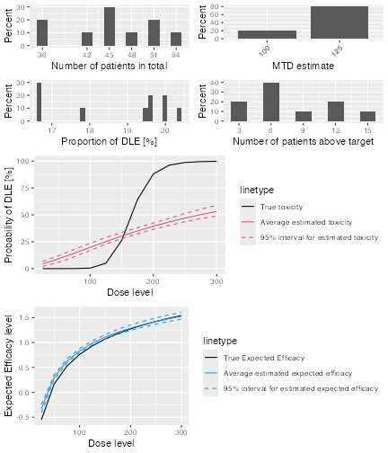

```r
print(plot(Sum2))
```

```r
Sum3 <- summary(Sim3,
  trueDLE = myTruthDLT,
  trueEff = myTruthEff1
)
Sum3
```

```
#> Summary of 10 simulations
#>
#> Target probability of DLE p(DLE) used at the end of a trial was 30 %
#> The dose level corresponds to the target p(DLE) used at the end of a trial, TDEOT, was 152.6195
#> TDEOT at dose Grid was 150
#> Target p(DLE) used during a trial was 35 %
#> The dose level corresponds to the target p(DLE) used during a trial, TDDT, was 155.972
#> TDDT at dose Grid was 150
#> Number of patients overall : mean 50 (39, 58)
#> Number of patients treated above the target p(DLE) used at the end of a trial : mean 8 (6, 12)
#> Number of patients treated above the target p(DLE) used during a trial : mean 8 (6, 12)
#> Proportions of observed DLT in the trials : mean 21 % (18 %, 24 %)
#> Mean toxicity risks for the patients : mean 20 % (15 %, 24 %)
#> Doses selected as TDEOT : mean 115 (100, 125)
#> True toxicity at TDEOT : mean 3 % (1 %, 5 %)
#> Proportion of trials selecting the TDEOT: 0 %
#> Proportion of trials selecting the TDDT: 0 %
#> Dose most often selected as TDEOT: 125
#> Observed toxicity rate at dose most often selected: 4 %
#> Fitted probabilities of DLE at dose most often selected : mean 27 % (25 %, 28 %)
#> The summary table of the final TDEOT across all simulations
#>     Min. 1st Qu.  Median    Mean 3rd Qu.    Max.
#>    113.1   123.7   127.0   127.0   130.0   137.2
#> The summary table of the final ratios of the TDEOT across all simulations
#>     Min. 1st Qu.  Median    Mean 3rd Qu.    Max.
#>        1       1       1       1       1       1
#> The summary table of the final TDDT across all simulations
#>     Min. 1st Qu.  Median    Mean 3rd Qu.    Max.
#>    128.9   143.6   149.2   149.0   154.4   169.5
#> The summary table of dose levels, the optimal dose
#>  to recommend for subsequent study across all simulations
#>     Min. 1st Qu.  Median    Mean 3rd Qu.    Max.
#>    113.1   123.7   127.0   127.0   130.0   137.2
#> The summary table of the final ratios of the optimal dose for stopping across
#>                   all simulations
#>     Min. 1st Qu.  Median    Mean 3rd Qu.    Max.
#>        1       1       1       1       1       1
#>
#> Stop reason triggered:
#>  GStar 5 for 0.3 target prob :  100 %
#>  ≥ 72 patients dosed :  0 %
#> Target Gstar, the dose which gives the maximum gain value was 125
#> Target Gstar at dose Grid was 125
#> The summary table of the final Gstar across all simulations
#>     Min. 1st Qu.  Median    Mean 3rd Qu.    Max.
#>    250.0   250.0   250.0   262.5   275.0   300.0
#> The summary table of the final ratios of the Gstar across all simulations
#>     Min. 1st Qu.  Median    Mean 3rd Qu.    Max.
#>    1.333   1.500   1.857   1.938   2.000   3.000
#> The summary table of dose levels, the optimal dose
#>  to recommend for subsequent study across all simulations
#>     Min. 1st Qu.  Median    Mean 3rd Qu.    Max.
#>    113.1   123.7   127.0   127.0   130.0   137.2
#> The summary table of the final ratios of the optimal dose for stopping across
#>         all simulations
#>     Min. 1st Qu.  Median    Mean 3rd Qu.    Max.
#>        1       1       1       1       1       1
#> Fitted expected efficacy level at dose most often selected : mean 0.9 (0.9, 1)
#> Stop reason triggered:
#>  GStar 5 for 0.3 target prob :  100 %
#>  ≥ 72 patients dosed :  0 %
```

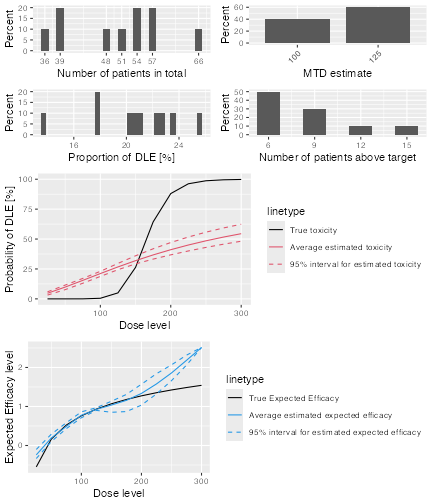

```r
print(plot(Sum3))
```

```r
# nolint end
```

As a reminder, for the dual endpoint dose escalation design which uses two separate models to describe the dose-responses relationship, the gain function is used to determine the next best dose and the final recommended dose at the end of a trial. More specifically at the end of a trial, we will recommend the dose level closest below which is the minimum of final estimate of the TD30 (TDtargetEndOfTrial) and Gstar.

For the scenario of last simulation, `Sim3`, we have the same real TD30 and the real Gstar is 125 mg. Since the real TD30 is greater than the real Gstar, we will also expect recommendations should be made close to the real Gstar under this scenario. We can see that from the simulated results in the summary or the plot of summary, the procedure also recommends 125 mg most often in the simulations, which agrees with our real scenario.

# References

Neuenschwander, Beat, Michael Branson, and Thomas Gsponer. 2008. “Critical aspects of the Bayesian approach to phase I cancer trials.” *Statistics in Medicine* 27 (13): 2420–39. https://onlinelibrary.wiley.com/doi/10.1002/sim.3230.

Whitehead, J., and D. Williamson. 1998. “Bayesian decision procedures based on logistic regression models for dose-finding studies.” *Journal of Biopharmaceutical Statistics* 8 (3): 445–67.

Yeung, W. Y., J. Whitehead, B. Reigner, U. Beyer, C. Diack, and T. Jaki. 2015. “Bayesian Adaptive Dose-Escalation Procedure for Binary and Continuous Responses Utilizing a Gain Function.” *Pharmaceutical Statistics*.